# Dose_Dependence

```r
library(tidyverse)
library(janitor)
library(naniar)
library(lubridate)
```

#dose_dependence dataset

```r
dose_dependence<-read_csv("doi_10_25338_B8BS75__v20210727/dose_dependence_data.csv")%>%
  clean_names()
glimpse(dose_dependence)
```

```
## Rows: 168
## Columns: 16
## $ trial_date            <chr> "01.16.20", "01.16.20", "01.16.20", "01.16.20", …
## $ image_id              <chr> "a1", "a2", "a3", "b1", "b2", "b3", "c1", "c2", …
## $ microbetreatment      <chr> "(undiluted)", "(undiluted)", "(undiluted)", "(1…
## $ assay_replicate       <dbl> 1, 2, 3, 1, 2, 3, 1, 2, 3, 1, 2, 3, 1, 2, 3, 1, …
## $ timepoint             <chr> "15m", "15m", "15m", "15m", "15m", "15m", "15m",…
## $ minutes               <dbl> 15, 15, 15, 15, 15, 15, 15, 15, 15, 15, 15, 15, …
## $ initial_od            <dbl> 0.10000000, 0.10000000, 0.10000000, 0.05000000, …
## $ total_pollen          <dbl> 24, 23, 21, 20, 27, 26, 23, 21, 19, 39, 39, 24, …
## $ number_germ           <dbl> 0, 0, 0, 1, 0, 1, 0, 0, 0, 0, 0, 0, 0, 0, 0, 0, …
## $ number_burst          <dbl> 1, 0, 0, 1, 0, 0, 0, 0, 0, 0, 1, 0, 1, 0, 0, 0, …
## $ number_tip_burst      <dbl> 0, 0, 0, 0, 0, 0, 0, 0, 0, 0, 0, 0, 0, 0, 0, 0, …
## $ proportion_germinated <dbl> 0.00000000, 0.00000000, 0.00000000, 0.05000000, …
## $ proportion_burst      <dbl> 0.04166667, 0.00000000, 0.00000000, 0.05000000, …
## $ proportion_tip_burst  <dbl> 0.00000000, 0.00000000, 0.00000000, 0.00000000, …
## $ allgerm               <dbl> 0.00000000, 0.00000000, 0.00000000, 0.05000000, …
## $ allburst              <dbl> 0.04166667, 0.00000000, 0.00000000, 0.05000000, …
```

```r
summary(dose_dependence)
```

```
##   trial_date          image_id         microbetreatment   assay_replicate
##  Length:168         Length:168         Length:168         Min.   :1
##  Class :character   Class :character   Class :character   1st Qu.:1
##  Mode  :character   Mode  :character   Mode  :character   Median :2
##                                                           Mean   :2
##                                                           3rd Qu.:3
##                                                           Max.   :3
##
##   timepoint            minutes          initial_od      total_pollen
##  Length:168         Min.   :  15.00   Min.   :0.0000   Min.   :11.00
##  Class :character   1st Qu.:  78.75   1st Qu.:0.0010   1st Qu.:33.00
##  Mode  :character   Median : 210.00   Median :0.0200   Median :43.00
##                     Mean   : 386.25   Mean   :0.0299   Mean   :45.35
##                     3rd Qu.: 450.00   3rd Qu.:0.0500   3rd Qu.:57.00
##                     Max.   :1440.00   Max.   :0.1000   Max.   :87.00
##
##   number_germ      number_burst   number_tip_burst proportion_germinated
##  Min.   : 0.000   Min.   :0.000   Min.   : 0.000   Min.   :0.00000
##  1st Qu.: 0.000   1st Qu.:0.000   1st Qu.: 0.000   1st Qu.:0.00000
##  Median : 3.000   Median :1.000   Median : 3.000   Median :0.07596
##  Mean   : 4.536   Mean   :1.024   Mean   : 5.533   Mean   :0.09556
##  3rd Qu.: 8.000   3rd Qu.:2.000   3rd Qu.:10.500   3rd Qu.:0.16044
##  Max.   :23.000   Max.   :4.000   Max.   :29.000   Max.   :0.48148
##                                   NA's   :1
##  proportion_burst  proportion_tip_burst    allgerm          allburst
##  Min.   :0.00000   Min.   :0.00000      Min.   :0.0000   Min.   :0.00000
##  1st Qu.:0.00000   1st Qu.:0.00000      1st Qu.:0.0000   1st Qu.:0.00000
##  Median :0.01539   Median :0.04633      Median :0.2338   Median :0.07524
##  Mean   :0.02152   Mean   :0.11758      Mean   :0.2131   Mean   :0.13911
##  3rd Qu.:0.03469   3rd Qu.:0.24074      3rd Qu.:0.3818   3rd Qu.:0.25569
##  Max.   :0.09524   Max.   :0.41935      Max.   :0.5417   Max.   :0.43333
##
```

- actually microbe treatment and initial OD is the same but only the initial OD make the treatment into a number #graph of mircriobe treatment vs. germinated -examine how is the proportion germinated change for each time point and microbetreatment
- undiluted appears to have higher germination <=3h
  - after 3h —> competition?
  - burst?
- 1:20 have higher germination >3h

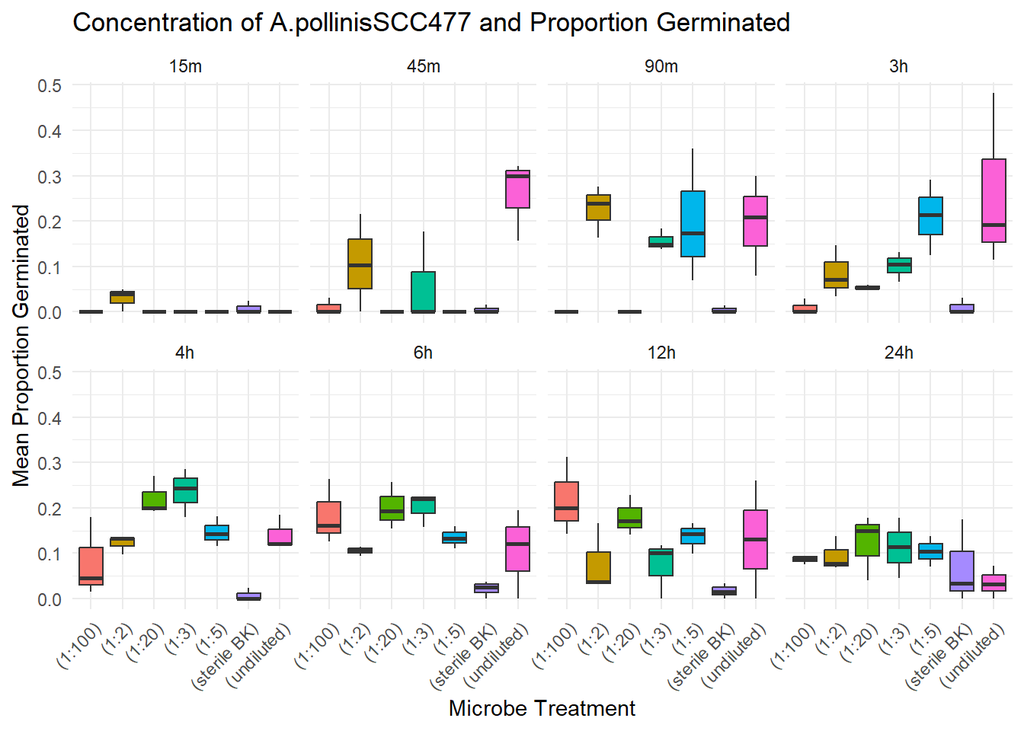

```r
dose_dependence%>%
  mutate(timepoint=factor(timepoint,
         levels=c("15m","45m","90m","3h","4h","6h","12h","24h")))%>%
  ggplot(aes(x=microbetreatment,
             y=proportion_germinated,
             fill=microbetreatment))+
  geom_boxplot()+
  facet_wrap(~timepoint, nrow=2)+
  theme_minimal()+
  labs(title="Concentration of A.pollinisSCC477 and Proportion Germinated",
       x="Microbe Treatment",
       y="Mean Proportion Germinated")+
  theme(legend.position="none",
        axis.text.x=element_text(angle=45, hjust=1))
```

- undiluted appears to maintained its position in proportion of germinated if using allgerm(The proportion of pollen grains that germinated, including both “number.germ” and “number.tip.burst”) -maybe many pollen quickly being burst - might indicated higher concentration increase both bursting and germination

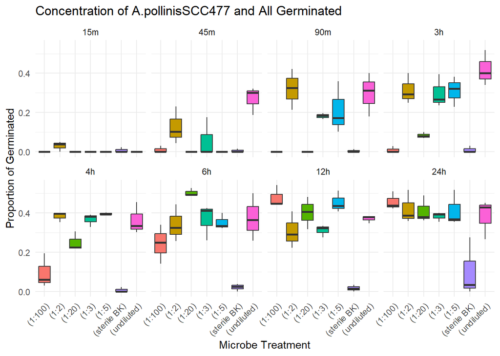

```r
dose_dependence %>%
  mutate(timepoint=factor(timepoint,
         levels=c("15m","45m","90m","3h","4h","6h","12h","24h")))%>%
  ggplot(aes(x=microbetreatment,
             y=allgerm,
             fill=microbetreatment))+
  geom_boxplot()+
  facet_wrap(~timepoint, nrow=2)+
  labs(title="Concentration of A.pollinisSCC477 and All Germinated",
       x="Microbe Treatment",
       y="Proportion of Germinated")+
  theme_minimal()+
  theme(legend.position="none",
        axis.text.x=element_text(angle=45, hjust=1))
```

#whether treatment accelerates germination - make time point to same unit

```r
dose_dependence <- dose_dependence %>%
  mutate(time_minutes=case_when(
    timepoint=="15m" ~ 15,
           timepoint=="45m" ~ 45,
           timepoint=="90m" ~ 90,
           timepoint=="3h"  ~ 180,
           timepoint=="4h"  ~ 240,
           timepoint=="6h"  ~ 360,
           timepoint=="12h" ~ 720,
           timepoint=="24h" ~ 1440))
```

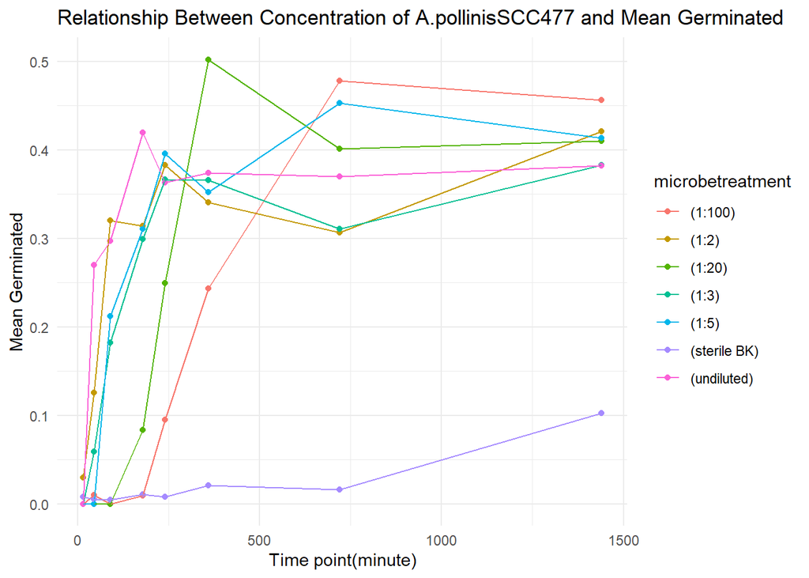

```r
dose_dependence%>%
  group_by(microbetreatment, time_minutes)%>%
  summarize(mean_germ=mean(allgerm, na.rm=TRUE)) %>%
  ggplot(aes(x=time_minutes,
             y=mean_germ,
             color=microbetreatment))+
  geom_point()+
  geom_line()+
  labs(
    title="Relationship Between Concentration of A.pollinisSCC477 and Mean Germinated",
    x="Time point(minute)",
    y="Mean Germinated")+
  theme_minimal()
```

#graph of mircriobe treatment vs. brust - longer time –> more burst - higher concentration —> more bursting

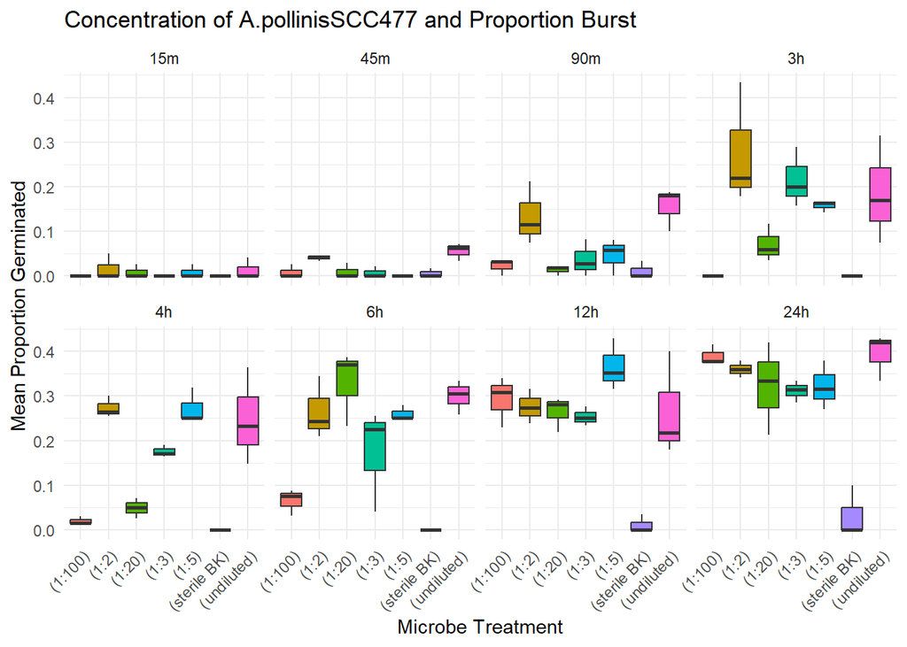

```r
dose_dependence%>%
  mutate(timepoint=factor(timepoint,
         levels=c("15m","45m","90m","3h","4h","6h","12h","24h")))%>%
  ggplot(aes(x=microbetreatment,
             y=allburst,
             fill=microbetreatment))+
  geom_boxplot()+
  facet_wrap(~timepoint, nrow=2)+
  theme_minimal()+
  labs(title="Concentration of A.pollinisSCC477 and Proportion Burst",
       x="Microbe Treatment",
       y="Mean Proportion Germinated")+
  theme(legend.position="none",
        axis.text.x=element_text(angle=45, hjust=1))
```

#graph of initial OD vs. germination - removed sterile BK because its od is 0 - repetitive with above graph

```r
#dose_dependence%>%
#  filter(microbetreatment!="sterile BK") %>%
#  mutate(timepoint=factor(timepoint,
#         levels=c("15m","45m","90m","3h","4h","6h","12h","24h"))) %>%
#  pivot_longer(
#    cols=c(allgerm, allburst),
#    names_to="response",
#    values_to="value")%>%
#  ggplot(aes(x = factor(initial_od), y = value)) +
#  geom_boxplot(fill = "lightblue") +
#  facet_grid(response ~ timepoint) +
#  theme_minimal() +
#  labs(
#    title="Relationship Between Initial OD and Germination/Bursting",
#    x ="Initial OD",
#    y ="Proportion")+
# theme(axis.text.x = element_text(angle = 45, hjust = 1))
```

#relationship between brust and germination -not so useful graph–> don’t use

```r
#dose_dependence%>%
#  mutate(timepoint=factor(timepoint,
#         levels=c("15m","45m","90m","3h","4h","6h","12h","24h")))%>%
#  ggplot(aes(x=allgerm,
#             y=allburst,
#             color=microbetreatment))+
#  geom_point()+
#  geom_smooth(method=lm, se=F)+
#  facet_wrap(~timepoint, nrow=2)+
#  theme(legend.position="bottom")+
#  labs(
#    title="Relationship between Germination and Bursting",
#    x="Proportion Germinated",
#    y="Proportion Burst",
#    color="Microbe Treatment")
```